# Risk Factor Analysis

## Outcome Variable

**Outcome Variable:** ever_swasted

## Predictor Variables

**Intervention Variable:** month

**Adjustment Set:**

unadjusted

## Stratifying Variables

The analysis was stratified on these variable(s):

- agecat
- studyid
- country

## Data Summary

| agecat | studyid | country | month | ever_swasted | n_cell | n |
| --- | --- | --- | --- | --- | --- | --- |
| 0-24 months (no birth wast) | ki0047075b-MAL-ED | BANGLADESH | 1 | 0 | 21 | 261 |
| 0-24 months (no birth wast) | ki0047075b-MAL-ED | BANGLADESH | 1 | 1 | 0 | 261 |
| 0-24 months (no birth wast) | ki0047075b-MAL-ED | BANGLADESH | 2 | 0 | 23 | 261 |
| 0-24 months (no birth wast) | ki0047075b-MAL-ED | BANGLADESH | 2 | 1 | 1 | 261 |
| 0-24 months (no birth wast) | ki0047075b-MAL-ED | BANGLADESH | 3 | 0 | 22 | 261 |
| 0-24 months (no birth wast) | ki0047075b-MAL-ED | BANGLADESH | 3 | 1 | 4 | 261 |
| 0-24 months (no birth wast) | ki0047075b-MAL-ED | BANGLADESH | 4 | 0 | 21 | 261 |
| 0-24 months (no birth wast) | ki0047075b-MAL-ED | BANGLADESH | 4 | 1 | 1 | 261 |
| 0-24 months (no birth wast) | ki0047075b-MAL-ED | BANGLADESH | 5 | 0 | 21 | 261 |
| 0-24 months (no birth wast) | ki0047075b-MAL-ED | BANGLADESH | 5 | 1 | 1 | 261 |
| 0-24 months (no birth wast) | ki0047075b-MAL-ED | BANGLADESH | 6 | 0 | 9 | 261 |
| 0-24 months (no birth wast) | ki0047075b-MAL-ED | BANGLADESH | 6 | 1 | 0 | 261 |
| 0-24 months (no birth wast) | ki0047075b-MAL-ED | BANGLADESH | 7 | 0 | 21 | 261 |
| 0-24 months (no birth wast) | ki0047075b-MAL-ED | BANGLADESH | 7 | 1 | 1 | 261 |
| 0-24 months (no birth wast) | ki0047075b-MAL-ED | BANGLADESH | 8 | 0 | 25 | 261 |
| 0-24 months (no birth wast) | ki0047075b-MAL-ED | BANGLADESH | 8 | 1 | 0 | 261 |
| 0-24 months (no birth wast) | ki0047075b-MAL-ED | BANGLADESH | 9 | 0 | 22 | 261 |
| 0-24 months (no birth wast) | ki0047075b-MAL-ED | BANGLADESH | 9 | 1 | 1 | 261 |
| 0-24 months (no birth wast) | ki0047075b-MAL-ED | BANGLADESH | 10 | 0 | 21 | 261 |
| 0-24 months (no birth wast) | ki0047075b-MAL-ED | BANGLADESH | 10 | 1 | 2 | 261 |
| 0-24 months (no birth wast) | ki0047075b-MAL-ED | BANGLADESH | 11 | 0 | 17 | 261 |
| 0-24 months (no birth wast) | ki0047075b-MAL-ED | BANGLADESH | 11 | 1 | 0 | 261 |
| 0-24 months (no birth wast) | ki0047075b-MAL-ED | BANGLADESH | 12 | 0 | 26 | 261 |
| 0-24 months (no birth wast) | ki0047075b-MAL-ED | BANGLADESH | 12 | 1 | 1 | 261 |
| 0-24 months (no birth wast) | ki0047075b-MAL-ED | BRAZIL | 1 | 0 | 13 | 229 |
| 0-24 months (no birth wast) | ki0047075b-MAL-ED | BRAZIL | 1 | 1 | 0 | 229 |
| 0-24 months (no birth wast) | ki0047075b-MAL-ED | BRAZIL | 2 | 0 | 26 | 229 |
| 0-24 months (no birth wast) | ki0047075b-MAL-ED | BRAZIL | 2 | 1 | 0 | 229 |
| 0-24 months (no birth wast) | ki0047075b-MAL-ED | BRAZIL | 3 | 0 | 21 | 229 |
| 0-24 months (no birth wast) | ki0047075b-MAL-ED | BRAZIL | 3 | 1 | 0 | 229 |

[output cut: 1962 more lines]

The following strata were considered:

- agecat: 0-24 months (no birth wast), studyid: ki0047075b-MAL-ED, country: BANGLADESH
- agecat: 0-24 months (no birth wast), studyid: ki0047075b-MAL-ED, country: BRAZIL
- agecat: 0-24 months (no birth wast), studyid: ki0047075b-MAL-ED, country: INDIA
- agecat: 0-24 months (no birth wast), studyid: ki0047075b-MAL-ED, country: NEPAL
- agecat: 0-24 months (no birth wast), studyid: ki0047075b-MAL-ED, country: PERU
- agecat: 0-24 months (no birth wast), studyid: ki0047075b-MAL-ED, country: SOUTH AFRICA
- agecat: 0-24 months (no birth wast), studyid: ki0047075b-MAL-ED, country: TANZANIA, UNITED REPUBLIC OF
- agecat: 0-24 months (no birth wast), studyid: ki1000108-CMC-V-BCS-2002, country: INDIA
- agecat: 0-24 months (no birth wast), studyid: ki1000108-IRC, country: INDIA
- agecat: 0-24 months (no birth wast), studyid: ki1000109-EE, country: PAKISTAN
- agecat: 0-24 months (no birth wast), studyid: ki1000109-ResPak, country: PAKISTAN
- agecat: 0-24 months (no birth wast), studyid: ki1000304b-SAS-CompFeed, country: INDIA
- agecat: 0-24 months (no birth wast), studyid: ki1000304b-SAS-FoodSuppl, country: INDIA
- agecat: 0-24 months (no birth wast), studyid: ki1017093-NIH-Birth, country: BANGLADESH
- agecat: 0-24 months (no birth wast), studyid: ki1066203-TanzaniaChild2, country: TANZANIA, UNITED REPUBLIC OF
- agecat: 0-24 months (no birth wast), studyid: ki1112895-Guatemala BSC, country: GUATEMALA
- agecat: 0-24 months (no birth wast), studyid: ki1112895-iLiNS-Zinc, country: BURKINA FASO
- agecat: 0-24 months (no birth wast), studyid: ki1113344-GMS-Nepal, country: NEPAL
- agecat: 0-24 months (no birth wast), studyid: ki1114097-CMIN, country: BANGLADESH
- agecat: 0-24 months (no birth wast), studyid: ki1114097-CMIN, country: BRAZIL
- agecat: 0-24 months (no birth wast), studyid: ki1114097-CMIN, country: GUINEA-BISSAU
- agecat: 0-24 months (no birth wast), studyid: ki1114097-CMIN, country: PERU
- agecat: 0-24 months (no birth wast), studyid: ki1114097-CONTENT, country: PERU
- agecat: 0-24 months (no birth wast), studyid: ki1119695-PROBIT, country: BELARUS
- agecat: 0-24 months (no birth wast), studyid: ki1126311-ZVITAMBO, country: ZIMBABWE
- agecat: 0-24 months (no birth wast), studyid: ki1148112-LCNI-5, country: MALAWI
- agecat: 0-24 months (no birth wast), studyid: kiGH5241-JiVitA-3, country: BANGLADESH
- agecat: 0-24 months (no birth wast), studyid: kiGH5241-JiVitA-4, country: BANGLADESH
- agecat: 0-6 months (no birth wast), studyid: ki0047075b-MAL-ED, country: BANGLADESH
- agecat: 0-6 months (no birth wast), studyid: ki0047075b-MAL-ED, country: BRAZIL
- agecat: 0-6 months (no birth wast), studyid: ki0047075b-MAL-ED, country: INDIA
- agecat: 0-6 months (no birth wast), studyid: ki0047075b-MAL-ED, country: NEPAL
- agecat: 0-6 months (no birth wast), studyid: ki0047075b-MAL-ED, country: PERU
- agecat: 0-6 months (no birth wast), studyid: ki0047075b-MAL-ED, country: SOUTH AFRICA
- agecat: 0-6 months (no birth wast), studyid: ki0047075b-MAL-ED, country: TANZANIA, UNITED REPUBLIC OF
- agecat: 0-6 months (no birth wast), studyid: ki1000108-CMC-V-BCS-2002, country: INDIA
- agecat: 0-6 months (no birth wast), studyid: ki1000108-IRC, country: INDIA
- agecat: 0-6 months (no birth wast), studyid: ki1000109-EE, country: PAKISTAN
- agecat: 0-6 months (no birth wast), studyid: ki1000109-ResPak, country: PAKISTAN
- agecat: 0-6 months (no birth wast), studyid: ki1000304b-SAS-CompFeed, country: INDIA
- agecat: 0-6 months (no birth wast), studyid: ki1000304b-SAS-FoodSuppl, country: INDIA
- agecat: 0-6 months (no birth wast), studyid: ki1017093-NIH-Birth, country: BANGLADESH
- agecat: 0-6 months (no birth wast), studyid: ki1066203-TanzaniaChild2, country: TANZANIA, UNITED REPUBLIC OF
- agecat: 0-6 months (no birth wast), studyid: ki1112895-Guatemala BSC, country: GUATEMALA
- agecat: 0-6 months (no birth wast), studyid: ki1113344-GMS-Nepal, country: NEPAL
- agecat: 0-6 months (no birth wast), studyid: ki1114097-CMIN, country: BANGLADESH
- agecat: 0-6 months (no birth wast), studyid: ki1114097-CMIN, country: BRAZIL
- agecat: 0-6 months (no birth wast), studyid: ki1114097-CMIN, country: GUINEA-BISSAU
- agecat: 0-6 months (no birth wast), studyid: ki1114097-CMIN, country: PERU
- agecat: 0-6 months (no birth wast), studyid: ki1114097-CONTENT, country: PERU
- agecat: 0-6 months (no birth wast), studyid: ki1119695-PROBIT, country: BELARUS
- agecat: 0-6 months (no birth wast), studyid: ki1126311-ZVITAMBO, country: ZIMBABWE
- agecat: 0-6 months (no birth wast), studyid: ki1148112-LCNI-5, country: MALAWI
- agecat: 0-6 months (no birth wast), studyid: kiGH5241-JiVitA-3, country: BANGLADESH
- agecat: 0-6 months (no birth wast), studyid: kiGH5241-JiVitA-4, country: BANGLADESH
- agecat: 6-24 months, studyid: ki0047075b-MAL-ED, country: BANGLADESH
- agecat: 6-24 months, studyid: ki0047075b-MAL-ED, country: BRAZIL
- agecat: 6-24 months, studyid: ki0047075b-MAL-ED, country: INDIA
- agecat: 6-24 months, studyid: ki0047075b-MAL-ED, country: NEPAL
- agecat: 6-24 months, studyid: ki0047075b-MAL-ED, country: PERU
- agecat: 6-24 months, studyid: ki0047075b-MAL-ED, country: SOUTH AFRICA
- agecat: 6-24 months, studyid: ki0047075b-MAL-ED, country: TANZANIA, UNITED REPUBLIC OF
- agecat: 6-24 months, studyid: ki1000108-CMC-V-BCS-2002, country: INDIA
- agecat: 6-24 months, studyid: ki1000108-IRC, country: INDIA
- agecat: 6-24 months, studyid: ki1000109-EE, country: PAKISTAN
- agecat: 6-24 months, studyid: ki1000109-ResPak, country: PAKISTAN
- agecat: 6-24 months, studyid: ki1000304b-SAS-CompFeed, country: INDIA
- agecat: 6-24 months, studyid: ki1000304b-SAS-FoodSuppl, country: INDIA
- agecat: 6-24 months, studyid: ki1017093-NIH-Birth, country: BANGLADESH
- agecat: 6-24 months, studyid: ki1066203-TanzaniaChild2, country: TANZANIA, UNITED REPUBLIC OF
- agecat: 6-24 months, studyid: ki1112895-Guatemala BSC, country: GUATEMALA
- agecat: 6-24 months, studyid: ki1112895-iLiNS-Zinc, country: BURKINA FASO
- agecat: 6-24 months, studyid: ki1113344-GMS-Nepal, country: NEPAL
- agecat: 6-24 months, studyid: ki1114097-CMIN, country: BANGLADESH
- agecat: 6-24 months, studyid: ki1114097-CMIN, country: BRAZIL
- agecat: 6-24 months, studyid: ki1114097-CMIN, country: GUINEA-BISSAU
- agecat: 6-24 months, studyid: ki1114097-CMIN, country: PERU
- agecat: 6-24 months, studyid: ki1114097-CONTENT, country: PERU
- agecat: 6-24 months, studyid: ki1119695-PROBIT, country: BELARUS
- agecat: 6-24 months, studyid: ki1126311-ZVITAMBO, country: ZIMBABWE
- agecat: 6-24 months, studyid: ki1148112-LCNI-5, country: MALAWI
- agecat: 6-24 months, studyid: kiGH5241-JiVitA-3, country: BANGLADESH
- agecat: 6-24 months, studyid: kiGH5241-JiVitA-4, country: BANGLADESH

### Dropped Strata

Some strata were dropped due to rare outcomes:

- agecat: 0-24 months (no birth wast), studyid: ki0047075b-MAL-ED, country: BANGLADESH
- agecat: 0-24 months (no birth wast), studyid: ki0047075b-MAL-ED, country: BRAZIL
- agecat: 0-24 months (no birth wast), studyid: ki0047075b-MAL-ED, country: INDIA
- agecat: 0-24 months (no birth wast), studyid: ki0047075b-MAL-ED, country: NEPAL
- agecat: 0-24 months (no birth wast), studyid: ki0047075b-MAL-ED, country: PERU
- agecat: 0-24 months (no birth wast), studyid: ki0047075b-MAL-ED, country: SOUTH AFRICA
- agecat: 0-24 months (no birth wast), studyid: ki0047075b-MAL-ED, country: TANZANIA, UNITED REPUBLIC OF
- agecat: 0-24 months (no birth wast), studyid: ki1000108-CMC-V-BCS-2002, country: INDIA
- agecat: 0-24 months (no birth wast), studyid: ki1000108-IRC, country: INDIA
- agecat: 0-24 months (no birth wast), studyid: ki1000109-EE, country: PAKISTAN
- agecat: 0-24 months (no birth wast), studyid: ki1000109-ResPak, country: PAKISTAN
- agecat: 0-24 months (no birth wast), studyid: ki1000304b-SAS-CompFeed, country: INDIA
- agecat: 0-24 months (no birth wast), studyid: ki1000304b-SAS-FoodSuppl, country: INDIA
- agecat: 0-24 months (no birth wast), studyid: ki1017093-NIH-Birth, country: BANGLADESH
- agecat: 0-24 months (no birth wast), studyid: ki1112895-Guatemala BSC, country: GUATEMALA
- agecat: 0-24 months (no birth wast), studyid: ki1112895-iLiNS-Zinc, country: BURKINA FASO
- agecat: 0-24 months (no birth wast), studyid: ki1113344-GMS-Nepal, country: NEPAL
- agecat: 0-24 months (no birth wast), studyid: ki1114097-CMIN, country: BANGLADESH
- agecat: 0-24 months (no birth wast), studyid: ki1114097-CMIN, country: BRAZIL
- agecat: 0-24 months (no birth wast), studyid: ki1114097-CMIN, country: GUINEA-BISSAU
- agecat: 0-24 months (no birth wast), studyid: ki1114097-CMIN, country: PERU
- agecat: 0-24 months (no birth wast), studyid: ki1114097-CONTENT, country: PERU
- agecat: 0-24 months (no birth wast), studyid: ki1119695-PROBIT, country: BELARUS
- agecat: 0-24 months (no birth wast), studyid: ki1148112-LCNI-5, country: MALAWI
- agecat: 0-24 months (no birth wast), studyid: kiGH5241-JiVitA-4, country: BANGLADESH
- agecat: 0-6 months (no birth wast), studyid: ki0047075b-MAL-ED, country: BANGLADESH
- agecat: 0-6 months (no birth wast), studyid: ki0047075b-MAL-ED, country: BRAZIL
- agecat: 0-6 months (no birth wast), studyid: ki0047075b-MAL-ED, country: INDIA
- agecat: 0-6 months (no birth wast), studyid: ki0047075b-MAL-ED, country: NEPAL
- agecat: 0-6 months (no birth wast), studyid: ki0047075b-MAL-ED, country: PERU
- agecat: 0-6 months (no birth wast), studyid: ki0047075b-MAL-ED, country: SOUTH AFRICA
- agecat: 0-6 months (no birth wast), studyid: ki0047075b-MAL-ED, country: TANZANIA, UNITED REPUBLIC OF
- agecat: 0-6 months (no birth wast), studyid: ki1000108-CMC-V-BCS-2002, country: INDIA
- agecat: 0-6 months (no birth wast), studyid: ki1000108-IRC, country: INDIA
- agecat: 0-6 months (no birth wast), studyid: ki1000109-EE, country: PAKISTAN
- agecat: 0-6 months (no birth wast), studyid: ki1000109-ResPak, country: PAKISTAN
- agecat: 0-6 months (no birth wast), studyid: ki1000304b-SAS-CompFeed, country: INDIA
- agecat: 0-6 months (no birth wast), studyid: ki1000304b-SAS-FoodSuppl, country: INDIA
- agecat: 0-6 months (no birth wast), studyid: ki1017093-NIH-Birth, country: BANGLADESH
- agecat: 0-6 months (no birth wast), studyid: ki1066203-TanzaniaChild2, country: TANZANIA, UNITED REPUBLIC OF
- agecat: 0-6 months (no birth wast), studyid: ki1112895-Guatemala BSC, country: GUATEMALA
- agecat: 0-6 months (no birth wast), studyid: ki1113344-GMS-Nepal, country: NEPAL
- agecat: 0-6 months (no birth wast), studyid: ki1114097-CMIN, country: BANGLADESH
- agecat: 0-6 months (no birth wast), studyid: ki1114097-CMIN, country: BRAZIL
- agecat: 0-6 months (no birth wast), studyid: ki1114097-CMIN, country: GUINEA-BISSAU
- agecat: 0-6 months (no birth wast), studyid: ki1114097-CMIN, country: PERU
- agecat: 0-6 months (no birth wast), studyid: ki1114097-CONTENT, country: PERU
- agecat: 0-6 months (no birth wast), studyid: ki1119695-PROBIT, country: BELARUS
- agecat: 0-6 months (no birth wast), studyid: ki1126311-ZVITAMBO, country: ZIMBABWE
- agecat: 0-6 months (no birth wast), studyid: ki1148112-LCNI-5, country: MALAWI
- agecat: 0-6 months (no birth wast), studyid: kiGH5241-JiVitA-4, country: BANGLADESH
- agecat: 6-24 months, studyid: ki0047075b-MAL-ED, country: BANGLADESH
- agecat: 6-24 months, studyid: ki0047075b-MAL-ED, country: BRAZIL
- agecat: 6-24 months, studyid: ki0047075b-MAL-ED, country: INDIA
- agecat: 6-24 months, studyid: ki0047075b-MAL-ED, country: NEPAL
- agecat: 6-24 months, studyid: ki0047075b-MAL-ED, country: PERU
- agecat: 6-24 months, studyid: ki0047075b-MAL-ED, country: SOUTH AFRICA
- agecat: 6-24 months, studyid: ki0047075b-MAL-ED, country: TANZANIA, UNITED REPUBLIC OF
- agecat: 6-24 months, studyid: ki1000108-CMC-V-BCS-2002, country: INDIA
- agecat: 6-24 months, studyid: ki1000108-IRC, country: INDIA
- agecat: 6-24 months, studyid: ki1000109-EE, country: PAKISTAN
- agecat: 6-24 months, studyid: ki1000109-ResPak, country: PAKISTAN
- agecat: 6-24 months, studyid: ki1000304b-SAS-CompFeed, country: INDIA
- agecat: 6-24 months, studyid: ki1000304b-SAS-FoodSuppl, country: INDIA
- agecat: 6-24 months, studyid: ki1017093-NIH-Birth, country: BANGLADESH
- agecat: 6-24 months, studyid: ki1066203-TanzaniaChild2, country: TANZANIA, UNITED REPUBLIC OF
- agecat: 6-24 months, studyid: ki1112895-Guatemala BSC, country: GUATEMALA
- agecat: 6-24 months, studyid: ki1112895-iLiNS-Zinc, country: BURKINA FASO
- agecat: 6-24 months, studyid: ki1113344-GMS-Nepal, country: NEPAL
- agecat: 6-24 months, studyid: ki1114097-CMIN, country: BANGLADESH
- agecat: 6-24 months, studyid: ki1114097-CMIN, country: BRAZIL
- agecat: 6-24 months, studyid: ki1114097-CMIN, country: GUINEA-BISSAU
- agecat: 6-24 months, studyid: ki1114097-CMIN, country: PERU
- agecat: 6-24 months, studyid: ki1114097-CONTENT, country: PERU
- agecat: 6-24 months, studyid: ki1119695-PROBIT, country: BELARUS
- agecat: 6-24 months, studyid: ki1148112-LCNI-5, country: MALAWI
- agecat: 6-24 months, studyid: kiGH5241-JiVitA-4, country: BANGLADESH

## Methods Detail

We’re interested in the causal parameters $E[Y_a]$ for all values of $a \in \mathcal{A}$. These parameters represent the mean outcome if, possibly contrary to fact, we intervened to set all units to have $A=a$. Under the randomization and positivity assumptions, these are identified by the statistical parameters $\psi_a=E_W[E_{Y|A,W}(Y|A=a,W)]$. In addition, we’re interested in the mean of $Y$, $E[Y]$ under no intervention (the observed mean). We will estimate these parameters by using SuperLearner to fit the relevant likelihood factors – $E_{Y|A,W}(Y|A=a,W)$ and $p(A=a|W)$, and then updating our likelihood fit using a joint TMLE.

For unadjusted analyses ($W=\{\}$), initial likelihoods were estimated using Lrnr_glm to estimate the simple $E(Y|A)$ and Lrnr_mean to estimate $p(A)$. For adjusted analyses, a small library containing Lrnr_glmnet, Lrnr_xgboost, and Lrnr_mean was used.

Having estimated these parameters, we will then use the delta method to estimate relative risks and attributable risks relative to a prespecified baseline level of $A$.

# Results Detail

## Results Plots

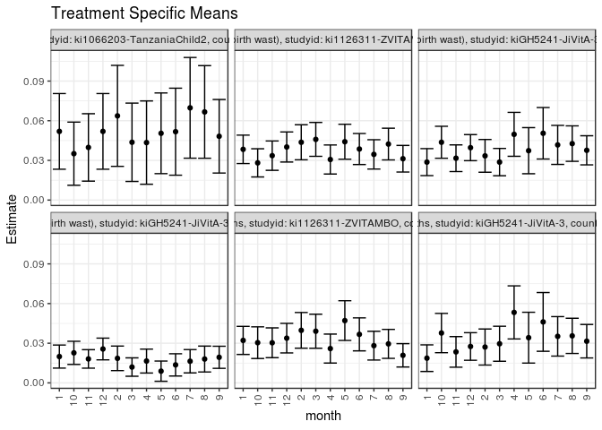

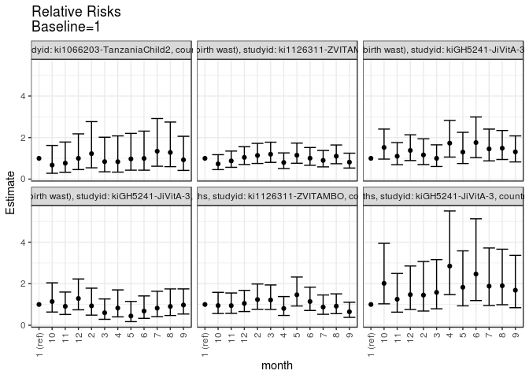

[figure not shown]

[figure not shown]

## Results Table

### Parameter: TSM

| agecat | studyid | country | intervention_level | baseline_level | estimate | ci_lower | ci_upper |
| --- | --- | --- | --- | --- | --- | --- | --- |
| 0-24 months (no birth wast) | ki1066203-TanzaniaChild2 | TANZANIA, UNITED REPUBLIC OF | 1 | NA | 0.0519481 | 0.0233238 | 0.0805723 |
| 0-24 months (no birth wast) | ki1066203-TanzaniaChild2 | TANZANIA, UNITED REPUBLIC OF | 2 | NA | 0.0636943 | 0.0254868 | 0.1019017 |
| 0-24 months (no birth wast) | ki1066203-TanzaniaChild2 | TANZANIA, UNITED REPUBLIC OF | 3 | NA | 0.0437158 | 0.0140862 | 0.0733455 |
| 0-24 months (no birth wast) | ki1066203-TanzaniaChild2 | TANZANIA, UNITED REPUBLIC OF | 4 | NA | 0.0434783 | 0.0119711 | 0.0749855 |
| 0-24 months (no birth wast) | ki1066203-TanzaniaChild2 | TANZANIA, UNITED REPUBLIC OF | 5 | NA | 0.0505051 | 0.0199966 | 0.0810135 |
| 0-24 months (no birth wast) | ki1066203-TanzaniaChild2 | TANZANIA, UNITED REPUBLIC OF | 6 | NA | 0.0517241 | 0.0188103 | 0.0846380 |
| 0-24 months (no birth wast) | ki1066203-TanzaniaChild2 | TANZANIA, UNITED REPUBLIC OF | 7 | NA | 0.0697674 | 0.0316874 | 0.1078475 |
| 0-24 months (no birth wast) | ki1066203-TanzaniaChild2 | TANZANIA, UNITED REPUBLIC OF | 8 | NA | 0.0666667 | 0.0316484 | 0.1016849 |
| 0-24 months (no birth wast) | ki1066203-TanzaniaChild2 | TANZANIA, UNITED REPUBLIC OF | 9 | NA | 0.0482456 | 0.0204252 | 0.0760660 |
| 0-24 months (no birth wast) | ki1066203-TanzaniaChild2 | TANZANIA, UNITED REPUBLIC OF | 10 | NA | 0.0350877 | 0.0111990 | 0.0589765 |
| 0-24 months (no birth wast) | ki1066203-TanzaniaChild2 | TANZANIA, UNITED REPUBLIC OF | 11 | NA | 0.0398230 | 0.0143237 | 0.0653223 |
| 0-24 months (no birth wast) | ki1066203-TanzaniaChild2 | TANZANIA, UNITED REPUBLIC OF | 12 | NA | 0.0519481 | 0.0233238 | 0.0805723 |
| 0-24 months (no birth wast) | ki1126311-ZVITAMBO | ZIMBABWE | 1 | NA | 0.0383673 | 0.0276105 | 0.0491241 |
| 0-24 months (no birth wast) | ki1126311-ZVITAMBO | ZIMBABWE | 2 | NA | 0.0437158 | 0.0304673 | 0.0569644 |
| 0-24 months (no birth wast) | ki1126311-ZVITAMBO | ZIMBABWE | 3 | NA | 0.0458984 | 0.0330807 | 0.0587162 |
| 0-24 months (no birth wast) | ki1126311-ZVITAMBO | ZIMBABWE | 4 | NA | 0.0306878 | 0.0196911 | 0.0416846 |
| 0-24 months (no birth wast) | ki1126311-ZVITAMBO | ZIMBABWE | 5 | NA | 0.0441335 | 0.0309254 | 0.0573416 |
| 0-24 months (no birth wast) | ki1126311-ZVITAMBO | ZIMBABWE | 6 | NA | 0.0386100 | 0.0268777 | 0.0503424 |
| 0-24 months (no birth wast) | ki1126311-ZVITAMBO | ZIMBABWE | 7 | NA | 0.0345489 | 0.0234594 | 0.0456385 |
| 0-24 months (no birth wast) | ki1126311-ZVITAMBO | ZIMBABWE | 8 | NA | 0.0423573 | 0.0303784 | 0.0543362 |
| 0-24 months (no birth wast) | ki1126311-ZVITAMBO | ZIMBABWE | 9 | NA | 0.0312772 | 0.0212208 | 0.0413335 |
| 0-24 months (no birth wast) | ki1126311-ZVITAMBO | ZIMBABWE | 10 | NA | 0.0281385 | 0.0174755 | 0.0388016 |
| 0-24 months (no birth wast) | ki1126311-ZVITAMBO | ZIMBABWE | 11 | NA | 0.0335968 | 0.0224948 | 0.0446989 |
| 0-24 months (no birth wast) | ki1126311-ZVITAMBO | ZIMBABWE | 12 | NA | 0.0401396 | 0.0287748 | 0.0515045 |
| 0-24 months (no birth wast) | kiGH5241-JiVitA-3 | BANGLADESH | 1 | NA | 0.0287121 | 0.0185065 | 0.0389177 |
| 0-24 months (no birth wast) | kiGH5241-JiVitA-3 | BANGLADESH | 2 | NA | 0.0334347 | 0.0210419 | 0.0458274 |
| 0-24 months (no birth wast) | kiGH5241-JiVitA-3 | BANGLADESH | 3 | NA | 0.0287162 | 0.0183791 | 0.0390534 |
| 0-24 months (no birth wast) | kiGH5241-JiVitA-3 | BANGLADESH | 4 | NA | 0.0497110 | 0.0331021 | 0.0663198 |
| 0-24 months (no birth wast) | kiGH5241-JiVitA-3 | BANGLADESH | 5 | NA | 0.0373563 | 0.0199132 | 0.0547994 |
| 0-24 months (no birth wast) | kiGH5241-JiVitA-3 | BANGLADESH | 6 | NA | 0.0505201 | 0.0310529 | 0.0699872 |
| 0-24 months (no birth wast) | kiGH5241-JiVitA-3 | BANGLADESH | 7 | NA | 0.0417227 | 0.0269652 | 0.0564803 |
| 0-24 months (no birth wast) | kiGH5241-JiVitA-3 | BANGLADESH | 8 | NA | 0.0427011 | 0.0292832 | 0.0561189 |
| 0-24 months (no birth wast) | kiGH5241-JiVitA-3 | BANGLADESH | 9 | NA | 0.0376344 | 0.0266239 | 0.0486450 |
| 0-24 months (no birth wast) | kiGH5241-JiVitA-3 | BANGLADESH | 10 | NA | 0.0437236 | 0.0316429 | 0.0558042 |
| 0-24 months (no birth wast) | kiGH5241-JiVitA-3 | BANGLADESH | 11 | NA | 0.0316586 | 0.0215756 | 0.0417417 |
| 0-24 months (no birth wast) | kiGH5241-JiVitA-3 | BANGLADESH | 12 | NA | 0.0396446 | 0.0297811 | 0.0495080 |
| 0-6 months (no birth wast) | kiGH5241-JiVitA-3 | BANGLADESH | 1 | NA | 0.0199170 | 0.0112004 | 0.0286336 |
| 0-6 months (no birth wast) | kiGH5241-JiVitA-3 | BANGLADESH | 2 | NA | 0.0185759 | 0.0092953 | 0.0278564 |
| 0-6 months (no birth wast) | kiGH5241-JiVitA-3 | BANGLADESH | 3 | NA | 0.0119760 | 0.0050253 | 0.0189268 |
| 0-6 months (no birth wast) | kiGH5241-JiVitA-3 | BANGLADESH | 4 | NA | 0.0165094 | 0.0074575 | 0.0255613 |
| 0-6 months (no birth wast) | kiGH5241-JiVitA-3 | BANGLADESH | 5 | NA | 0.0088757 | 0.0012268 | 0.0165247 |
| 0-6 months (no birth wast) | kiGH5241-JiVitA-3 | BANGLADESH | 6 | NA | 0.0136157 | 0.0051984 | 0.0220331 |
| 0-6 months (no birth wast) | kiGH5241-JiVitA-3 | BANGLADESH | 7 | NA | 0.0163711 | 0.0075434 | 0.0251988 |
| 0-6 months (no birth wast) | kiGH5241-JiVitA-3 | BANGLADESH | 8 | NA | 0.0180361 | 0.0082462 | 0.0278260 |
| 0-6 months (no birth wast) | kiGH5241-JiVitA-3 | BANGLADESH | 9 | NA | 0.0193648 | 0.0110214 | 0.0277083 |
| 0-6 months (no birth wast) | kiGH5241-JiVitA-3 | BANGLADESH | 10 | NA | 0.0227111 | 0.0139627 | 0.0314596 |
| 0-6 months (no birth wast) | kiGH5241-JiVitA-3 | BANGLADESH | 11 | NA | 0.0181311 | 0.0111365 | 0.0251257 |
| 0-6 months (no birth wast) | kiGH5241-JiVitA-3 | BANGLADESH | 12 | NA | 0.0256410 | 0.0174090 | 0.0338731 |
| 6-24 months | ki1126311-ZVITAMBO | ZIMBABWE | 1 | NA | 0.0321361 | 0.0215086 | 0.0427636 |
| 6-24 months | ki1126311-ZVITAMBO | ZIMBABWE | 2 | NA | 0.0397516 | 0.0262545 | 0.0532486 |
| 6-24 months | ki1126311-ZVITAMBO | ZIMBABWE | 3 | NA | 0.0390805 | 0.0262029 | 0.0519580 |
| 6-24 months | ki1126311-ZVITAMBO | ZIMBABWE | 4 | NA | 0.0259580 | 0.0150003 | 0.0369156 |
| 6-24 months | ki1126311-ZVITAMBO | ZIMBABWE | 5 | NA | 0.0471204 | 0.0320944 | 0.0621465 |
| 6-24 months | ki1126311-ZVITAMBO | ZIMBABWE | 6 | NA | 0.0366972 | 0.0242174 | 0.0491771 |
| 6-24 months | ki1126311-ZVITAMBO | ZIMBABWE | 7 | NA | 0.0281532 | 0.0172733 | 0.0390330 |
| 6-24 months | ki1126311-ZVITAMBO | ZIMBABWE | 8 | NA | 0.0295082 | 0.0185428 | 0.0404736 |
| 6-24 months | ki1126311-ZVITAMBO | ZIMBABWE | 9 | NA | 0.0208540 | 0.0120279 | 0.0296802 |
| 6-24 months | ki1126311-ZVITAMBO | ZIMBABWE | 10 | NA | 0.0304183 | 0.0184346 | 0.0424019 |
| 6-24 months | ki1126311-ZVITAMBO | ZIMBABWE | 11 | NA | 0.0303371 | 0.0190685 | 0.0416057 |
| 6-24 months | ki1126311-ZVITAMBO | ZIMBABWE | 12 | NA | 0.0338308 | 0.0226527 | 0.0450090 |
| 6-24 months | kiGH5241-JiVitA-3 | BANGLADESH | 1 | NA | 0.0187050 | 0.0086373 | 0.0287728 |
| 6-24 months | kiGH5241-JiVitA-3 | BANGLADESH | 2 | NA | 0.0271186 | 0.0134904 | 0.0407468 |
| 6-24 months | kiGH5241-JiVitA-3 | BANGLADESH | 3 | NA | 0.0296097 | 0.0163621 | 0.0428572 |
| 6-24 months | kiGH5241-JiVitA-3 | BANGLADESH | 4 | NA | 0.0533118 | 0.0332351 | 0.0733885 |
| 6-24 months | kiGH5241-JiVitA-3 | BANGLADESH | 5 | NA | 0.0342020 | 0.0149699 | 0.0534340 |
| 6-24 months | kiGH5241-JiVitA-3 | BANGLADESH | 6 | NA | 0.0461285 | 0.0239042 | 0.0683528 |
| 6-24 months | kiGH5241-JiVitA-3 | BANGLADESH | 7 | NA | 0.0352000 | 0.0202680 | 0.0501320 |
| 6-24 months | kiGH5241-JiVitA-3 | BANGLADESH | 8 | NA | 0.0355731 | 0.0222603 | 0.0488859 |
| 6-24 months | kiGH5241-JiVitA-3 | BANGLADESH | 9 | NA | 0.0315259 | 0.0188593 | 0.0441924 |
| 6-24 months | kiGH5241-JiVitA-3 | BANGLADESH | 10 | NA | 0.0377129 | 0.0228551 | 0.0525707 |
| 6-24 months | kiGH5241-JiVitA-3 | BANGLADESH | 11 | NA | 0.0234467 | 0.0118793 | 0.0350140 |
| 6-24 months | kiGH5241-JiVitA-3 | BANGLADESH | 12 | NA | 0.0275449 | 0.0171134 | 0.0379764 |

### Parameter: E(Y)

| agecat | studyid | country | intervention_level | baseline_level | estimate | ci_lower | ci_upper |
| --- | --- | --- | --- | --- | --- | --- | --- |
| 0-24 months (no birth wast) | ki1066203-TanzaniaChild2 | TANZANIA, UNITED REPUBLIC OF | NA | NA | 0.0507550 | 0.0419422 | 0.0595679 |
| 0-24 months (no birth wast) | ki1126311-ZVITAMBO | ZIMBABWE | NA | NA | 0.0376357 | 0.0342906 | 0.0409808 |
| 0-24 months (no birth wast) | kiGH5241-JiVitA-3 | BANGLADESH | NA | NA | 0.0379708 | 0.0341625 | 0.0417790 |
| 0-6 months (no birth wast) | kiGH5241-JiVitA-3 | BANGLADESH | NA | NA | 0.0183079 | 0.0155421 | 0.0210736 |
| 6-24 months | ki1126311-ZVITAMBO | ZIMBABWE | NA | NA | 0.0325150 | 0.0291498 | 0.0358802 |
| 6-24 months | kiGH5241-JiVitA-3 | BANGLADESH | NA | NA | 0.0328463 | 0.0285768 | 0.0371158 |

### Parameter: RR

| agecat | studyid | country | intervention_level | baseline_level | estimate | ci_lower | ci_upper |
| --- | --- | --- | --- | --- | --- | --- | --- |
| 0-24 months (no birth wast) | ki1066203-TanzaniaChild2 | TANZANIA, UNITED REPUBLIC OF | 1 | 1 | 1.0000000 | 1.0000000 | 1.000000 |
| 0-24 months (no birth wast) | ki1066203-TanzaniaChild2 | TANZANIA, UNITED REPUBLIC OF | 2 | 1 | 1.2261146 | 0.5429854 | 2.768688 |
| 0-24 months (no birth wast) | ki1066203-TanzaniaChild2 | TANZANIA, UNITED REPUBLIC OF | 3 | 1 | 0.8415301 | 0.3513284 | 2.015700 |
| 0-24 months (no birth wast) | ki1066203-TanzaniaChild2 | TANZANIA, UNITED REPUBLIC OF | 4 | 1 | 0.8369565 | 0.3367733 | 2.080023 |
| 0-24 months (no birth wast) | ki1066203-TanzaniaChild2 | TANZANIA, UNITED REPUBLIC OF | 5 | 1 | 0.9722222 | 0.4292140 | 2.202202 |
| 0-24 months (no birth wast) | ki1066203-TanzaniaChild2 | TANZANIA, UNITED REPUBLIC OF | 6 | 1 | 0.9956897 | 0.4290988 | 2.310419 |
| 0-24 months (no birth wast) | ki1066203-TanzaniaChild2 | TANZANIA, UNITED REPUBLIC OF | 7 | 1 | 1.3430233 | 0.6183742 | 2.916861 |
| 0-24 months (no birth wast) | ki1066203-TanzaniaChild2 | TANZANIA, UNITED REPUBLIC OF | 8 | 1 | 1.2833333 | 0.5994102 | 2.747608 |
| 0-24 months (no birth wast) | ki1066203-TanzaniaChild2 | TANZANIA, UNITED REPUBLIC OF | 9 | 1 | 0.9287281 | 0.4183156 | 2.061926 |
| 0-24 months (no birth wast) | ki1066203-TanzaniaChild2 | TANZANIA, UNITED REPUBLIC OF | 10 | 1 | 0.6754386 | 0.2813200 | 1.621703 |
| 0-24 months (no birth wast) | ki1066203-TanzaniaChild2 | TANZANIA, UNITED REPUBLIC OF | 11 | 1 | 0.7665929 | 0.3293741 | 1.784186 |
| 0-24 months (no birth wast) | ki1066203-TanzaniaChild2 | TANZANIA, UNITED REPUBLIC OF | 12 | 1 | 1.0000000 | 0.4587476 | 2.179848 |
| 0-24 months (no birth wast) | ki1126311-ZVITAMBO | ZIMBABWE | 1 | 1 | 1.0000000 | 1.0000000 | 1.000000 |
| 0-24 months (no birth wast) | ki1126311-ZVITAMBO | ZIMBABWE | 2 | 1 | 1.1394024 | 0.7540090 | 1.721780 |
| 0-24 months (no birth wast) | ki1126311-ZVITAMBO | ZIMBABWE | 3 | 1 | 1.1962891 | 0.8053388 | 1.777025 |
| 0-24 months (no birth wast) | ki1126311-ZVITAMBO | ZIMBABWE | 4 | 1 | 0.7998424 | 0.5074651 | 1.260674 |
| 0-24 months (no birth wast) | ki1126311-ZVITAMBO | ZIMBABWE | 5 | 1 | 1.1502874 | 0.7633235 | 1.733421 |
| 0-24 months (no birth wast) | ki1126311-ZVITAMBO | ZIMBABWE | 6 | 1 | 1.0063255 | 0.6655492 | 1.521587 |
| 0-24 months (no birth wast) | ki1126311-ZVITAMBO | ZIMBABWE | 7 | 1 | 0.9004778 | 0.5880088 | 1.378993 |
| 0-24 months (no birth wast) | ki1126311-ZVITAMBO | ZIMBABWE | 8 | 1 | 1.1039928 | 0.7413436 | 1.644042 |
| 0-24 months (no birth wast) | ki1126311-ZVITAMBO | ZIMBABWE | 9 | 1 | 0.8152023 | 0.5321063 | 1.248914 |
| 0-24 months (no birth wast) | ki1126311-ZVITAMBO | ZIMBABWE | 10 | 1 | 0.7333978 | 0.4577398 | 1.175061 |
| 0-24 months (no birth wast) | ki1126311-ZVITAMBO | ZIMBABWE | 11 | 1 | 0.8756623 | 0.5677158 | 1.350648 |
| 0-24 months (no birth wast) | ki1126311-ZVITAMBO | ZIMBABWE | 12 | 1 | 1.0461921 | 0.7023665 | 1.558329 |
| 0-24 months (no birth wast) | kiGH5241-JiVitA-3 | BANGLADESH | 1 | 1 | 1.0000000 | 1.0000000 | 1.000000 |
| 0-24 months (no birth wast) | kiGH5241-JiVitA-3 | BANGLADESH | 2 | 1 | 1.1644811 | 0.6987056 | 1.940755 |
| 0-24 months (no birth wast) | kiGH5241-JiVitA-3 | BANGLADESH | 3 | 1 | 1.0001448 | 0.6061181 | 1.650321 |
| 0-24 months (no birth wast) | kiGH5241-JiVitA-3 | BANGLADESH | 4 | 1 | 1.7313625 | 1.0612510 | 2.824606 |
| 0-24 months (no birth wast) | kiGH5241-JiVitA-3 | BANGLADESH | 5 | 1 | 1.3010673 | 0.7512424 | 2.253302 |
| 0-24 months (no birth wast) | kiGH5241-JiVitA-3 | BANGLADESH | 6 | 1 | 1.7595415 | 1.0347250 | 2.992086 |
| 0-24 months (no birth wast) | kiGH5241-JiVitA-3 | BANGLADESH | 7 | 1 | 1.4531436 | 0.8769230 | 2.407995 |
| 0-24 months (no birth wast) | kiGH5241-JiVitA-3 | BANGLADESH | 8 | 1 | 1.4872180 | 0.9445229 | 2.341730 |
| 0-24 months (no birth wast) | kiGH5241-JiVitA-3 | BANGLADESH | 9 | 1 | 1.3107527 | 0.8259904 | 2.080015 |
| 0-24 months (no birth wast) | kiGH5241-JiVitA-3 | BANGLADESH | 10 | 1 | 1.5228289 | 0.9628137 | 2.408574 |
| 0-24 months (no birth wast) | kiGH5241-JiVitA-3 | BANGLADESH | 11 | 1 | 1.1026251 | 0.6918926 | 1.757183 |
| 0-24 months (no birth wast) | kiGH5241-JiVitA-3 | BANGLADESH | 12 | 1 | 1.3807636 | 0.8938448 | 2.132930 |
| 0-6 months (no birth wast) | kiGH5241-JiVitA-3 | BANGLADESH | 1 | 1 | 1.0000000 | 1.0000000 | 1.000000 |
| 0-6 months (no birth wast) | kiGH5241-JiVitA-3 | BANGLADESH | 2 | 1 | 0.9326625 | 0.4872917 | 1.785090 |
| 0-6 months (no birth wast) | kiGH5241-JiVitA-3 | BANGLADESH | 3 | 1 | 0.6012974 | 0.2854208 | 1.266756 |
| 0-6 months (no birth wast) | kiGH5241-JiVitA-3 | BANGLADESH | 4 | 1 | 0.8289112 | 0.4038205 | 1.701483 |
| 0-6 months (no birth wast) | kiGH5241-JiVitA-3 | BANGLADESH | 5 | 1 | 0.4456361 | 0.1731245 | 1.147102 |
| 0-6 months (no birth wast) | kiGH5241-JiVitA-3 | BANGLADESH | 6 | 1 | 0.6836233 | 0.3312872 | 1.410682 |
| 0-6 months (no birth wast) | kiGH5241-JiVitA-3 | BANGLADESH | 7 | 1 | 0.8219645 | 0.4128383 | 1.636538 |
| 0-6 months (no birth wast) | kiGH5241-JiVitA-3 | BANGLADESH | 8 | 1 | 0.9055611 | 0.4687927 | 1.749262 |
| 0-6 months (no birth wast) | kiGH5241-JiVitA-3 | BANGLADESH | 9 | 1 | 0.9722760 | 0.5402256 | 1.749863 |
| 0-6 months (no birth wast) | kiGH5241-JiVitA-3 | BANGLADESH | 10 | 1 | 1.1402886 | 0.6363430 | 2.043329 |
| 0-6 months (no birth wast) | kiGH5241-JiVitA-3 | BANGLADESH | 11 | 1 | 0.9103324 | 0.5186905 | 1.597687 |
| 0-6 months (no birth wast) | kiGH5241-JiVitA-3 | BANGLADESH | 12 | 1 | 1.2873932 | 0.7434241 | 2.229388 |
| 6-24 months | ki1126311-ZVITAMBO | ZIMBABWE | 1 | 1 | 1.0000000 | 1.0000000 | 1.000000 |
| 6-24 months | ki1126311-ZVITAMBO | ZIMBABWE | 2 | 1 | 1.2369748 | 0.7700486 | 1.987026 |
| 6-24 months | ki1126311-ZVITAMBO | ZIMBABWE | 3 | 1 | 1.2160920 | 0.7624636 | 1.939607 |
| 6-24 months | ki1126311-ZVITAMBO | ZIMBABWE | 4 | 1 | 0.8077510 | 0.4724865 | 1.380911 |
| 6-24 months | ki1126311-ZVITAMBO | ZIMBABWE | 5 | 1 | 1.4662766 | 0.9261882 | 2.321307 |
| 6-24 months | ki1126311-ZVITAMBO | ZIMBABWE | 6 | 1 | 1.1419320 | 0.7106072 | 1.835063 |
| 6-24 months | ki1126311-ZVITAMBO | ZIMBABWE | 7 | 1 | 0.8760599 | 0.5267885 | 1.456905 |
| 6-24 months | ki1126311-ZVITAMBO | ZIMBABWE | 8 | 1 | 0.9182257 | 0.5583552 | 1.510039 |
| 6-24 months | ki1126311-ZVITAMBO | ZIMBABWE | 9 | 1 | 0.6489281 | 0.3792544 | 1.110357 |
| 6-24 months | ki1126311-ZVITAMBO | ZIMBABWE | 10 | 1 | 0.9465444 | 0.5659208 | 1.583166 |
| 6-24 months | ki1126311-ZVITAMBO | ZIMBABWE | 11 | 1 | 0.9440185 | 0.5741074 | 1.552272 |
| 6-24 months | ki1126311-ZVITAMBO | ZIMBABWE | 12 | 1 | 1.0527363 | 0.6596242 | 1.680129 |
| 6-24 months | kiGH5241-JiVitA-3 | BANGLADESH | 1 | 1 | 1.0000000 | 1.0000000 | 1.000000 |
| 6-24 months | kiGH5241-JiVitA-3 | BANGLADESH | 2 | 1 | 1.4498044 | 0.6847532 | 3.069621 |
| 6-24 months | kiGH5241-JiVitA-3 | BANGLADESH | 3 | 1 | 1.5829796 | 0.7927657 | 3.160864 |
| 6-24 months | kiGH5241-JiVitA-3 | BANGLADESH | 4 | 1 | 2.8501304 | 1.4763266 | 5.502335 |
| 6-24 months | kiGH5241-JiVitA-3 | BANGLADESH | 5 | 1 | 1.8284891 | 0.9336884 | 3.580822 |
| 6-24 months | kiGH5241-JiVitA-3 | BANGLADESH | 6 | 1 | 2.4661006 | 1.1864523 | 5.125914 |
| 6-24 months | kiGH5241-JiVitA-3 | BANGLADESH | 7 | 1 | 1.8818461 | 0.9519298 | 3.720174 |
| 6-24 months | kiGH5241-JiVitA-3 | BANGLADESH | 8 | 1 | 1.9017938 | 0.9877496 | 3.661677 |
| 6-24 months | kiGH5241-JiVitA-3 | BANGLADESH | 9 | 1 | 1.6854205 | 0.8447324 | 3.362772 |
| 6-24 months | kiGH5241-JiVitA-3 | BANGLADESH | 10 | 1 | 2.0161894 | 1.0306663 | 3.944069 |
| 6-24 months | kiGH5241-JiVitA-3 | BANGLADESH | 11 | 1 | 1.2534944 | 0.6297840 | 2.494900 |
| 6-24 months | kiGH5241-JiVitA-3 | BANGLADESH | 12 | 1 | 1.4725932 | 0.7598613 | 2.853851 |

### Parameter: PAR

| agecat | studyid | country | intervention_level | baseline_level | estimate | ci_lower | ci_upper |
| --- | --- | --- | --- | --- | --- | --- | --- |
| 0-24 months (no birth wast) | ki1066203-TanzaniaChild2 | TANZANIA, UNITED REPUBLIC OF | 1 | NA | -0.0011930 | -0.0283634 | 0.0259774 |
| 0-24 months (no birth wast) | ki1126311-ZVITAMBO | ZIMBABWE | 1 | NA | -0.0007316 | -0.0109346 | 0.0094714 |
| 0-24 months (no birth wast) | kiGH5241-JiVitA-3 | BANGLADESH | 1 | NA | 0.0092587 | -0.0005200 | 0.0190374 |
| 0-6 months (no birth wast) | kiGH5241-JiVitA-3 | BANGLADESH | 1 | NA | -0.0016091 | -0.0097137 | 0.0064954 |
| 6-24 months | ki1126311-ZVITAMBO | ZIMBABWE | 1 | NA | 0.0003789 | -0.0097144 | 0.0104721 |
| 6-24 months | kiGH5241-JiVitA-3 | BANGLADESH | 1 | NA | 0.0141413 | 0.0043226 | 0.0239599 |

### Parameter: PAF

| agecat | studyid | country | intervention_level | baseline_level | estimate | ci_lower | ci_upper |
| --- | --- | --- | --- | --- | --- | --- | --- |
| 0-24 months (no birth wast) | ki1066203-TanzaniaChild2 | TANZANIA, UNITED REPUBLIC OF | 1 | NA | -0.0235054 | -0.7267651 | 0.3933377 |
| 0-24 months (no birth wast) | ki1126311-ZVITAMBO | ZIMBABWE | 1 | NA | -0.0194401 | -0.3299983 | 0.2186020 |
| 0-24 months (no birth wast) | kiGH5241-JiVitA-3 | BANGLADESH | 1 | NA | 0.2438383 | -0.0618564 | 0.4615274 |
| 0-6 months (no birth wast) | kiGH5241-JiVitA-3 | BANGLADESH | 1 | NA | -0.0878926 | -0.6333287 | 0.2753997 |
| 6-24 months | ki1126311-ZVITAMBO | ZIMBABWE | 1 | NA | 0.0116527 | -0.3530409 | 0.2780481 |
| 6-24 months | kiGH5241-JiVitA-3 | BANGLADESH | 1 | NA | 0.4305282 | 0.0435504 | 0.6609354 |